# Effect of selective regime on gene expression in B. plicatilis

J. Ignacio Lucas Lledó

# Model 2

```r
qlf2  <- glmQLFTest(fit2, coef=2)
topTags(qlf2)
```

```
## Coefficient:  regimerandom
##                     logFC      logCPM         F       PValue          FDR
## TCONS_00039978 -4.6173714  0.22365985 143.91953 2.241241e-08 0.0007379285
## TCONS_00029769 -3.0470230  1.80520388 115.41217 8.260165e-08 0.0012992981
## TCONS_00040399  0.9179518  8.92887368 107.54159 1.247110e-07 0.0012992981
## TCONS_00021223 -2.8668066 -0.01397275 100.46951 1.849392e-07 0.0012992981
## TCONS_00011853 -2.5460496  2.93967442  99.34797 1.973118e-07 0.0012992981
## TCONS_00038529  0.9214999  7.16741454  88.34146 3.865922e-07 0.0021214249
## TCONS_00038865 -0.7311331  6.58265152  82.13746 5.839742e-07 0.0025255438
## TCONS_00003138 -0.9392902  4.42067867  72.58240 1.166432e-06 0.0025255438
## TCONS_00003251  0.7230441  6.33486902  71.10043 1.307644e-06 0.0025255438
## TCONS_00064027  1.0885549  5.50123439  70.94544 1.323522e-06 0.0025255438
```

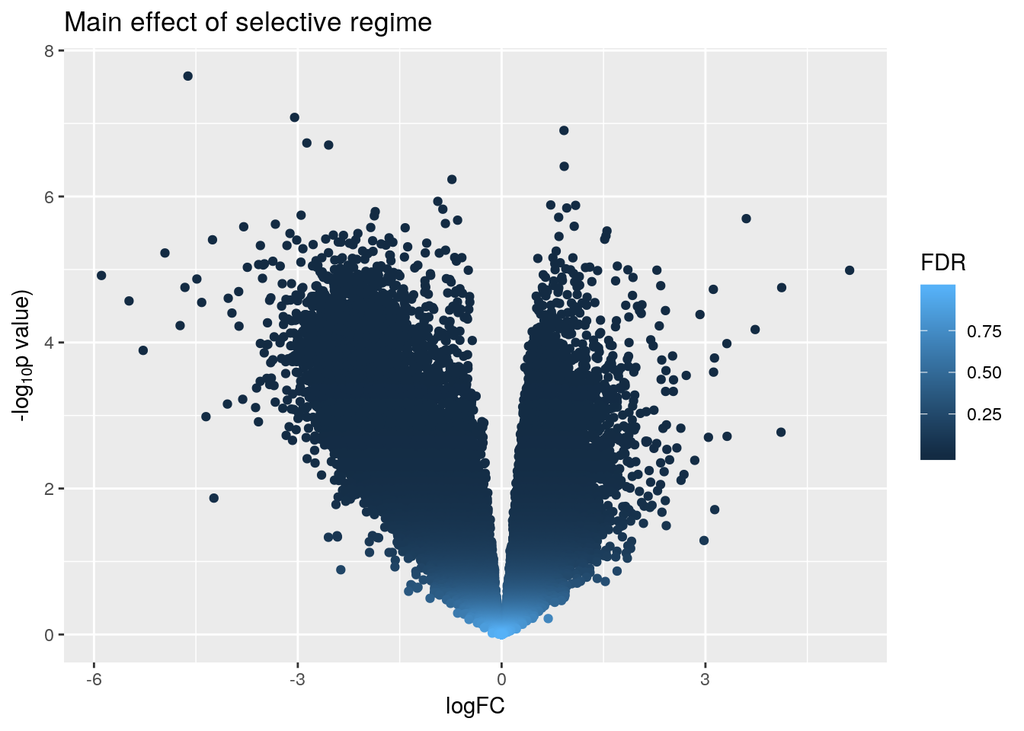

```r
z1 <- topTags(qlf2, n=NumOfTags)$table
z1$logPValue <- -log10(z1$PValue)
ggplot(data=z1, mapping=aes(x=logFC, y=logPValue, color=FDR)) +
   geom_point() + theme_grey() + ylab(expression(paste("-log"[10], plain("p value)")))) +
   ggtitle('Main effect of selective regime')
```

According to model 2, there are 6829 tags significantly up- or downregulated by selective regime at FDR=0.01.

# Model 3

Using model 3 I can look for genes affected by selective regime in two ways. First, I could look for a significant change in average gene expression among samples in the same regime. Alternatively, I could separately look for genes affected by the selective regime among samples in the same hatching condition, and then compare the lists of significant genes. According to Edu, the latter makes more sense biologically, because we expect the selective regime to affect different sets of genes depending on whether eggs are allowed to hatch or *forced* to undergo diapause.

## Effect of selective regime when eggs are allowed to hatch immediately

```r
qlf3a  <- glmQLFTest(fit3, contrast=c(-1, 0, 1, 0))
topTags(qlf3a)
```

```
## Coefficient:  -1*combinedRegulHatch 1*combinedRandHatch
##                     logFC     logCPM        F       PValue        FDR
## TCONS_00039978 -5.1017936  0.2230642 89.67057 7.136776e-07 0.02349784
## TCONS_00017559  1.3414218  5.6038378 66.75785 3.300492e-06 0.04048402
## TCONS_00044630 -2.2776795  3.7626651 65.31364 3.688749e-06 0.04048402
## TCONS_00047366 -1.8328896  7.0505776 59.01468 6.149849e-06 0.04953639
## TCONS_00035369 -2.7931628  2.2735303 54.93605 8.781579e-06 0.04953639
## TCONS_00040399  0.9600518  8.9288744 53.51970 9.989789e-06 0.04953639
## TCONS_00038529  1.0179935  7.1674161 52.63780 1.084032e-05 0.04953639
## TCONS_00047368 -1.9161628  5.0787282 51.52604 1.203618e-05 0.04953639
## TCONS_00021223 -2.9256229 -0.0143081 48.97599 1.541258e-05 0.05201875
## TCONS_00011853 -2.6218852  2.9395772 48.72635 1.579917e-05 0.05201875
```

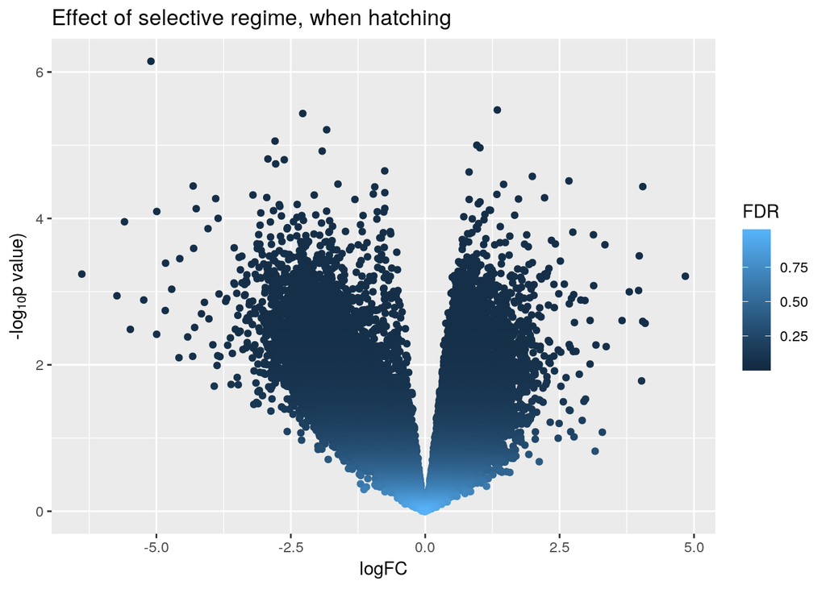

```r
z1 <- topTags(qlf3a, n=NumOfTags)$table
z1$logPValue <- -log10(z1$PValue)
ggplot(data=z1, mapping=aes(x=logFC, y=logPValue, color=FDR)) +
   geom_point() + theme_grey() + ylab(expression(paste("-log"[10], plain("p value)")))) +
   ggtitle('Effect of selective regime, when hatching')
```

According to model 3, contrast *a*, there are 8 tags differentially expressed between selective regimes among samples allowed to hatch immediately, at FDR=0.05.

## Effect of selective regime when eggs are forced to undergo diapause

```r
qlf3b  <- glmQLFTest(fit3, contrast=c(0, 1, 0, -1))
topTags(qlf3b)
```

```
## Coefficient:  1*combinedRandDiap -1*combinedRegulDiap
##                     logFC     logCPM        F       PValue        FDR
## TCONS_00029769 -3.2965960  1.8050729 66.72276 3.309341e-06 0.03606989
## TCONS_00039978 -4.1183780  0.2230642 61.02532 5.198752e-06 0.03606989
## TCONS_00065801  1.8348592  3.2085599 49.36062 1.483840e-05 0.03606989
## TCONS_00015560 -2.8069103  1.0279207 48.49532 1.616705e-05 0.03606989
## TCONS_00022801 -4.4660947 -0.2895002 47.08861 1.863619e-05 0.03606989
## TCONS_00016331 -3.0201067  4.0530687 45.12872 2.285137e-05 0.03606989
## TCONS_00040399  0.8758282  8.9288744 44.65223 2.403879e-05 0.03606989
## TCONS_00021223 -2.8048099 -0.0143081 43.57815 2.699036e-05 0.03606989
## TCONS_00029766 -2.8568208  0.2509729 42.81814 2.933617e-05 0.03606989
## TCONS_00011853 -2.4676627  2.9395772 42.69632 2.973397e-05 0.03606989
```

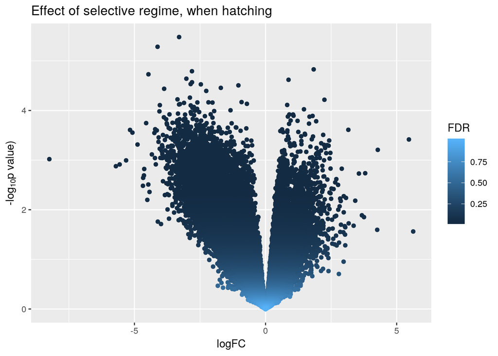

```r
z1 <- topTags(qlf3b, n=NumOfTags)$table
z1$logPValue <- -log10(z1$PValue)
ggplot(data=z1, mapping=aes(x=logFC, y=logPValue, color=FDR)) +
   geom_point() + theme_grey() + ylab(expression(paste("-log"[10], plain("p value)")))) +
   ggtitle('Effect of selective regime, when hatching')
```

According to model 3, contrast *b*, there are 5153 tags differentially expressed between selective regimes among samples undergoing diapause, at FDR=0.05. There is a reasonable correlation between the fold change in the two hatching conditions:

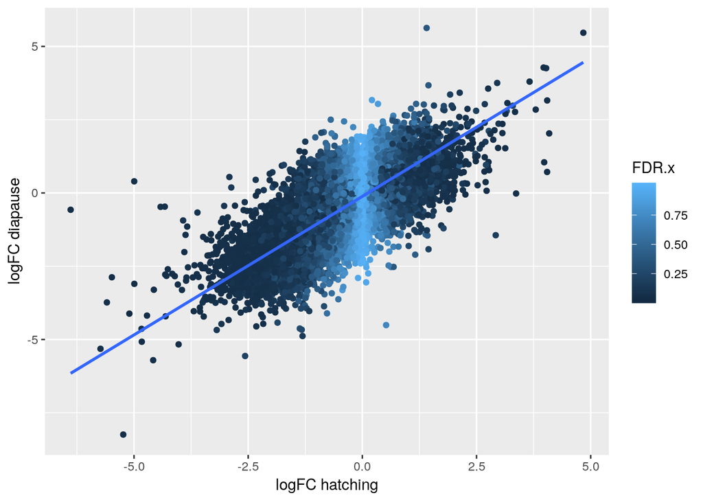

```r
z2 <- merge(topTags(qlf3a, n=NumOfTags)$table,
            topTags(qlf3b, n=NumOfTags)$table,
            by='row.names')
ggplot(data=z2, mapping=aes(x=logFC.x, y=logFC.y, color=FDR.x)) +
   geom_point() + geom_smooth(method='lm') + xlab('logFC hatching') + ylab('logFC diapause')
```

And this is the overlap between genes (or isoforms) affected by selective regime when hatching is immediate and those affected by selective regime when diapause is induced:

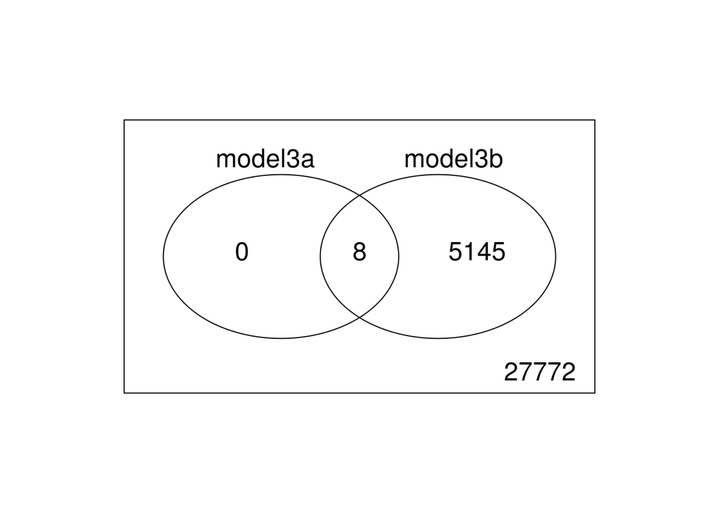

```r
significant <- cbind(model3a = topTags(qlf3a, n=NumOfTags, sort.by='none')$table$FDR <= 0.05,
                     model3b = topTags(qlf3b, n=NumOfTags, sort.by='none')$table$FDR <= 0.05)
vennDiagram(vennCounts(significant))
```

## Average effect of selective regime

```r
qlf3c  <- glmQLFTest(fit3, contrast=c(-0.5, 0.5, 0.5, -0.5))
topTags(qlf3c)
```

```
## Coefficient:  -0.5*combinedRegulHatch 0.5*combinedRandDiap 0.5*combinedRandHatch -0.5*combinedRegulDiap
##                     logFC     logCPM         F       PValue         FDR
## TCONS_00039978 -4.6100858  0.2230642 149.80524 4.448198e-08 0.001464569
## TCONS_00029769 -3.0390219  1.8050729 113.46353 2.029559e-07 0.003341162
## TCONS_00040399  0.9179400  8.9288744  97.98003 4.459972e-07 0.003776015
## TCONS_00021223 -2.8652164 -0.0143081  92.45974 6.069402e-07 0.003776015
## TCONS_00011853 -2.5447739  2.9395772  91.32577 6.479151e-07 0.003776015
## TCONS_00044630 -1.8588425  3.7626651  89.16237 7.354132e-07 0.003776015
## TCONS_00038529  0.9214048  7.1674161  86.47510 8.640700e-07 0.003776015
## TCONS_00017559  1.0681899  5.6038378  85.49388 9.174828e-07 0.003776015
## TCONS_00038865 -0.7311071  6.5826486  74.25493 1.911967e-06 0.004235884
## TCONS_00047366 -1.4304939  7.0505776  73.56959 2.005709e-06 0.004235884
```

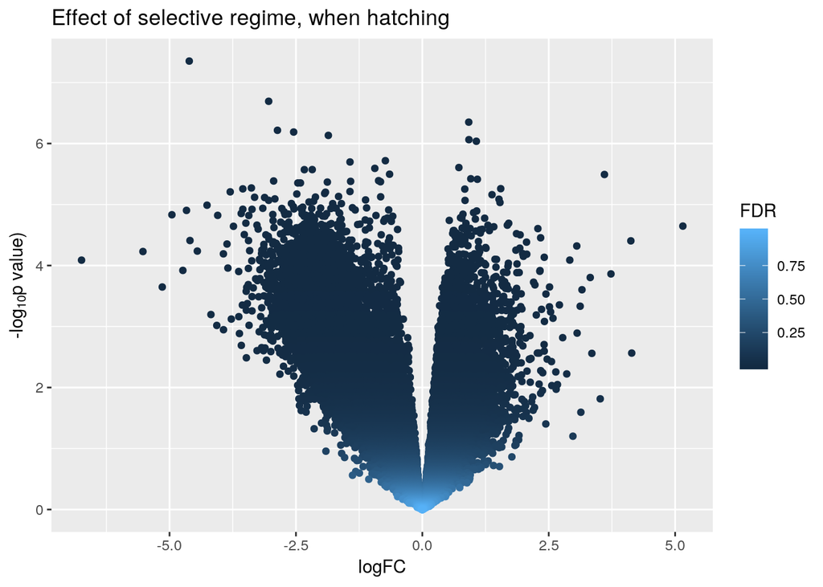

```r
z1 <- topTags(qlf3c, n=NumOfTags)$table
z1$logPValue <- -log10(z1$PValue)
ggplot(data=z1, mapping=aes(x=logFC, y=logPValue, color=FDR)) +
   geom_point() + theme_grey() + ylab(expression(paste("-log"[10], plain("p value)")))) +
   ggtitle('Effect of selective regime, when hatching')
```

# Model 4

```r
qlf4  <- glmQLFTest(fit4, coef=2)
topTags(qlf4)
```

```
## Coefficient:  regimerandom
##                    logFC     logCPM         F       PValue         FDR
## TCONS_00063463 -4.850396  5.7121325 257.42048 7.895530e-08 0.002599603
## TCONS_00030498 -2.058907  4.7766284 144.69230 9.043471e-07 0.011985955
## TCONS_00039988  4.490469  2.8430068 129.23447 1.448063e-06 0.011985955
## TCONS_00063464 -3.536331  3.4154358 129.06126 1.456152e-06 0.011985955
## TCONS_00054330 -2.657064  3.0068386  93.15814 5.560592e-06 0.032604375
## TCONS_00039977 -2.801475  3.9487953  88.76704 6.763264e-06 0.032604375
## TCONS_00032909  5.182826 -0.2673881  88.22861 6.931834e-06 0.032604375
## TCONS_00039966  5.307610  0.0114170  83.68888 8.579315e-06 0.035309245
## TCONS_00021071 -2.389116  5.1511425  75.54121 1.293601e-05 0.042853966
## TCONS_00017572  1.259235  7.1997413  74.94986 1.334797e-05 0.042853966
```

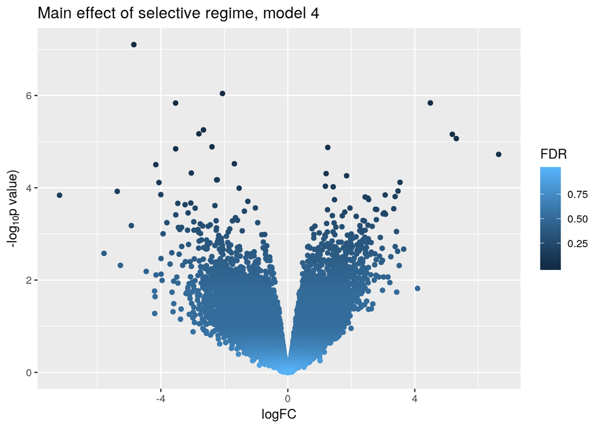

```r
z1 <- topTags(qlf4, n=NumOfTags)$table
z1$logPValue <- -log10(z1$PValue)
ggplot(data=z1, mapping=aes(x=logFC, y=logPValue, color=FDR)) +
   geom_point() + theme_grey() + ylab(expression(paste("-log"[10], plain("p value)")))) +
   ggtitle('Main effect of selective regime, model 4')
```

According to model 4, there are 56 tags significantly up- or downregulated by selective regime at FDR=0.25. I write the ordered list of genes with there fold change and p-values according to this model in a file, for later use in a functional enrichment analysis:

```r
write.table(topTags(qlf4, n=NumOfTags), file=sprintf("%s/regime.txt", args[2]), quote=FALSE)
```

# Model 5

```r
qlf5  <- glmQLFTest(fit5, coef=2)
topTags(qlf5)
```

```
## Coefficient:  regimerandom
##                     logFC     logCPM        F       PValue        FDR
## TCONS_00039978 -5.1017936  0.2230642 89.67057 7.136776e-07 0.02349784
## TCONS_00017559  1.3414218  5.6038378 66.75785 3.300492e-06 0.04048402
## TCONS_00044630 -2.2776795  3.7626651 65.31364 3.688749e-06 0.04048402
## TCONS_00047366 -1.8328896  7.0505776 59.01468 6.149849e-06 0.04953639
## TCONS_00035369 -2.7931628  2.2735303 54.93605 8.781579e-06 0.04953639
## TCONS_00040399  0.9600518  8.9288744 53.51970 9.989789e-06 0.04953639
## TCONS_00038529  1.0179935  7.1674161 52.63780 1.084032e-05 0.04953639
## TCONS_00047368 -1.9161628  5.0787282 51.52604 1.203618e-05 0.04953639
## TCONS_00021223 -2.9256229 -0.0143081 48.97599 1.541258e-05 0.05201875
## TCONS_00011853 -2.6218852  2.9395772 48.72635 1.579917e-05 0.05201875
```

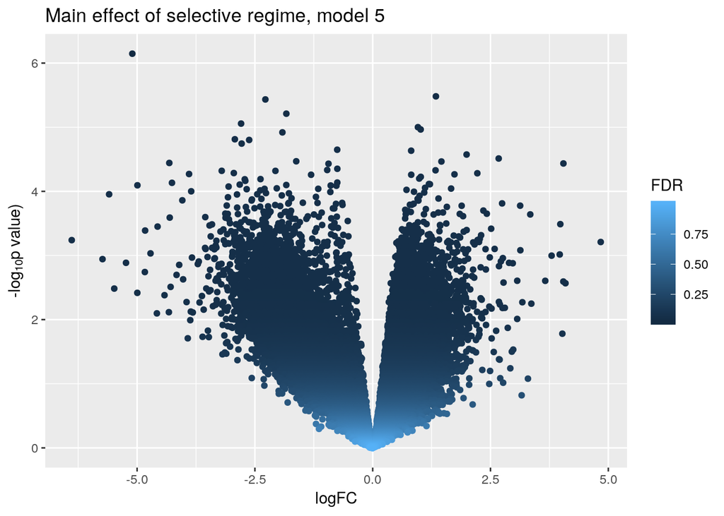

```r
z1 <- topTags(qlf5, n=NumOfTags)$table
z1$logPValue <- -log10(z1$PValue)
ggplot(data=z1, mapping=aes(x=logFC, y=logPValue, color=FDR)) +
   geom_point() + theme_grey() + ylab(expression(paste("-log"[10], plain("p value)")))) +
   ggtitle('Main effect of selective regime, model 5')
```

# Model 6

```r
qlf6  <- glmQLFTest(fit6, coef=2)
topTags(qlf6)
```

```
## Coefficient:  regimerandom
##                    logFC    logCPM         F       PValue        FDR
## TCONS_00039988  4.875488 2.8431918 191.89898 1.143071e-06 0.01914951
## TCONS_00063463 -4.759067 5.7121056 190.98820 1.163220e-06 0.01914951
## TCONS_00030498 -1.983166 4.7766054 100.29821 1.199481e-05 0.13164302
## TCONS_00063464 -3.550605 3.4153339  90.87423 1.702825e-05 0.14016382
## TCONS_00039977 -2.963986 3.9487155  78.19477 2.890161e-05 0.19031710
## TCONS_00054330 -2.539632 3.0065718  62.62136 6.243326e-05 0.30936540
## TCONS_00039978 -4.688132 0.2247422  61.67751 6.577245e-05 0.30936540
## TCONS_00039966  5.006618 0.0131614  59.00178 7.654774e-05 0.31504180
## TCONS_00068983 -3.266633 1.9384321  53.38159 1.075323e-04 0.33007703
## TCONS_00036683 -3.306312 1.9123751  52.65146 1.126476e-04 0.33007703
```

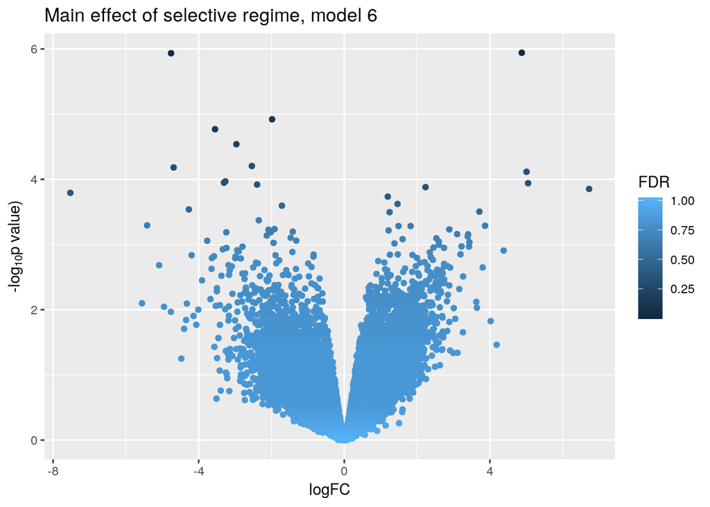

```r
z1 <- topTags(qlf6, n=NumOfTags)$table
z1$logPValue <- -log10(z1$PValue)
ggplot(data=z1, mapping=aes(x=logFC, y=logPValue, color=FDR)) +
   geom_point() + theme_grey() + ylab(expression(paste("-log"[10], plain("p value)")))) +
   ggtitle('Main effect of selective regime, model 6')
```

According to model 6, there are 5 tags significantly up- or downregulated by selective regime at FDR=0.25. And this is how the different models agree on what genes are differentially expressed in different selective regimes:

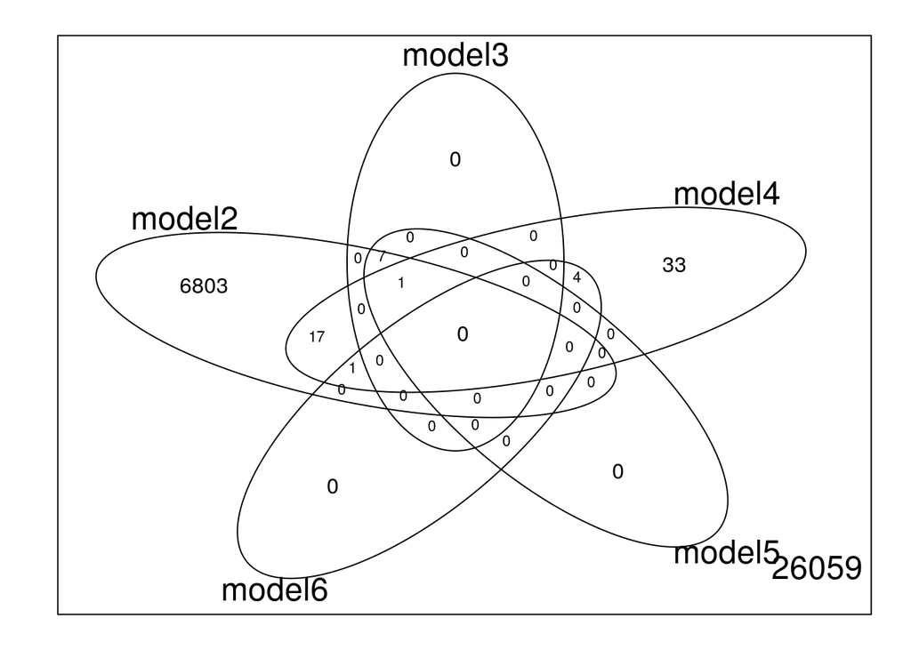

```r
significant <- cbind(model2 = topTags(qlf2,  n=NumOfTags, sort.by='none')$table$FDR <= 0.01,
                     model3 = topTags(qlf3a, n=NumOfTags, sort.by='none')$table$FDR <= 0.05,
                     model4 = topTags(qlf4,  n=NumOfTags, sort.by='none')$table$FDR <= 0.25,
                     model5 = topTags(qlf5,  n=NumOfTags, sort.by='none')$table$FDR <= 0.05,
                     model6 = topTags(qlf6,  n=NumOfTags, sort.by='none')$table$FDR <= 0.25)
vennDiagram(vennCounts(significant))
```

Note that I am using a different FDR for each model, to obtain more or less comparable and positive numbers.